# 고객 세분화

## 각 그룹별 구매금액 평균 구하기

```r
tapply(normal_client$CLNT_BUY_TOT, normal_client$CLNT_CL, mean)
```

```
## 10대 남성 10대 여성 20대 남성 20대 여성 30대 남성 30대 여성 40대 남성 40대 여성
##  143133.7  118520.9  149154.3  150651.2  162545.8  164739.3  171896.9  184091.8
## 50대 남성 50대 여성 60대 남성 60대 여성 70대 남성 70대 여성 80대 남성 80대 여성
##  176478.4  186996.9  163699.6  174338.3  166521.0  179709.7  205800.0  174161.7
```

## ANOVA 모형 적합

```r
fit.aov <- aov(CLNT_BUY_TOT ~ CLNT_CL, data = normal_client)
summary(fit.aov)
```

```
##                 Df            Sum Sq       Mean Sq F value              Pr(>F)
## CLNT_CL         15    88776213859400 5918414257293   297.1 <0.0000000000000002
## Residuals   599848 11949268418479096   19920493889
##
## CLNT_CL     ***
## Residuals
## ---
## Signif. codes:  0 '***' 0.001 '**' 0.01 '*' 0.05 '.' 0.1 ' ' 1
```

```r
# --> 대립가설이 채택되며, 고도로 유의하다.
# --> 집단간 평균 구매금액은 같지 않다.
# --> 어떤 집단들이 차이가 있는지 보기 위해 사후분석이 필요하다.
```

## 사후분석 - 평균의 다중비교

```r
library(multcomp)
fit.glht <- glht(fit.aov, linfct = mcp(CLNT_CL = 'Tukey'))

summary(fit.glht)
```

```
##
##   Simultaneous Tests for General Linear Hypotheses
##
## Multiple Comparisons of Means: Tukey Contrasts
##
##
## Fit: aov(formula = CLNT_BUY_TOT ~ CLNT_CL, data = normal_client)
##
## Linear Hypotheses:
##                            Estimate Std. Error t value Pr(>|t|)
## 10대 여성 - 10대 남성 == 0 -24612.9     5717.2  -4.305    <0.01 ***
## 20대 남성 - 10대 남성 == 0   6020.6     5245.0   1.148   0.9972
## 20대 여성 - 10대 남성 == 0   7517.5     5111.5   1.471   0.9675
## 30대 남성 - 10대 남성 == 0  19412.1     5137.5   3.778    <0.01 **
## 30대 여성 - 10대 남성 == 0  21605.5     5094.3   4.241    <0.01 **
## 40대 남성 - 10대 남성 == 0  28763.1     5148.1   5.587    <0.01 ***
## 40대 여성 - 10대 남성 == 0  40958.1     5099.0   8.033    <0.01 ***
## 50대 남성 - 10대 남성 == 0  33344.7     5370.1   6.209    <0.01 ***
## 50대 여성 - 10대 남성 == 0  43863.2     5166.0   8.491    <0.01 ***
## 60대 남성 - 10대 남성 == 0  20565.8     6436.0   3.195   0.0554 .
## 60대 여성 - 10대 남성 == 0  31204.6     5653.7   5.519    <0.01 ***
## 70대 남성 - 10대 남성 == 0  23387.3     9875.6   2.368   0.4302
## 70대 여성 - 10대 남성 == 0  36576.0     8208.0   4.456    <0.01 ***
## 80대 남성 - 10대 남성 == 0  62666.3    50159.1   1.249   0.9931
## 80대 여성 - 10대 남성 == 0  31027.9    33653.6   0.922   0.9998
## 20대 남성 - 10대 여성 == 0  30633.5     2907.6  10.536    <0.01 ***
## 20대 여성 - 10대 여성 == 0  32130.4     2659.3  12.082    <0.01 ***
## 30대 남성 - 10대 여성 == 0  44024.9     2709.0  16.251    <0.01 ***
## 30대 여성 - 10대 여성 == 0  46218.4     2626.0  17.600    <0.01 ***
## 40대 남성 - 10대 여성 == 0  53376.0     2729.0  19.559    <0.01 ***
## 40대 여성 - 10대 여성 == 0  65570.9     2635.1  24.883    <0.01 ***
## 50대 남성 - 10대 여성 == 0  57957.6     3127.7  18.530    <0.01 ***
## 50대 여성 - 10대 여성 == 0  68476.1     2762.6  24.787    <0.01 ***
## 60대 남성 - 10대 여성 == 0  45178.7     4729.3   9.553    <0.01 ***
## 60대 여성 - 10대 여성 == 0  55817.4     3592.9  15.536    <0.01 ***
## 70대 남성 - 10대 여성 == 0  48000.1     8858.4   5.419    <0.01 ***
## 70대 여성 - 10대 여성 == 0  61188.8     6951.0   8.803    <0.01 ***
## 80대 남성 - 10대 여성 == 0  87279.1    49968.8   1.747   0.8752
## 80대 여성 - 10대 여성 == 0  55640.8    33369.3   1.667   0.9109
## 20대 여성 - 20대 남성 == 0   1496.9     1377.1   1.087   0.9985
```

[output cut: 78 more lines]

```
## 80대 남성 - 60대 남성 == 0  42100.4    50056.1   0.841   0.9999
## 80대 여성 - 60대 남성 == 0  10462.1    33499.9   0.312   1.0000
## 70대 남성 - 60대 여성 == 0  -7817.3     8817.6  -0.887   0.9999
## 70대 여성 - 60대 여성 == 0   5371.4     6898.9   0.779   1.0000
## 80대 남성 - 60대 여성 == 0  31461.7    49961.5   0.630   1.0000
## 80대 여성 - 60대 여성 == 0   -176.6    33358.5  -0.005   1.0000
## 70대 여성 - 70대 남성 == 0  13188.7    10637.6   1.240   0.9937
## 80대 남성 - 70대 남성 == 0  39279.0    50613.4   0.776   1.0000
## 80대 여성 - 70대 남성 == 0   7640.7    34327.1   0.223   1.0000
## 80대 남성 - 70대 여성 == 0  26090.3    50314.6   0.519   1.0000
## 80대 여성 - 70대 여성 == 0  -5548.0    33885.0  -0.164   1.0000
## 80대 여성 - 80대 남성 == 0 -31638.3    59973.0  -0.528   1.0000
## ---
## Signif. codes:  0 '***' 0.001 '**' 0.01 '*' 0.05 '.' 0.1 ' ' 1
## (Adjusted p values reported -- single-step method)
```

## 사후분석 시각화

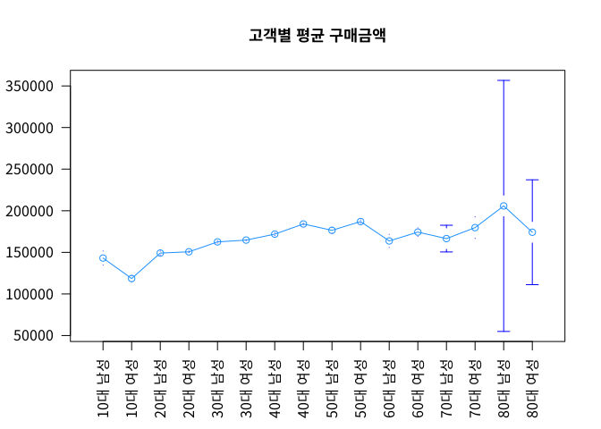

```r
library(gplots)
par(las = 2)
plotmeans(formula = CLNT_BUY_TOT ~ CLNT_CL,
          data = normal_client,
          cex.main=1.1,
          ylab = "",
          xlab = "",
          main = "고객별 평균 구매금액",
          col = 'dodgerblue',
          n.label = F)
```

```r
TukeyHSD(fit.aov)
```

```
##   Tukey multiple comparisons of means
##     95% family-wise confidence level
##
## Fit: aov(formula = CLNT_BUY_TOT ~ CLNT_CL, data = normal_client)
##
## $CLNT_CL
##                            diff          lwr        upr     p adj
## 10대 여성-10대 남성 -24612.8583  -44200.0664  -5025.650 0.0017899
## 20대 남성-10대 남성   6020.5979  -11948.9967  23990.193 0.9989992
## 20대 여성-10대 남성   7517.5119   -9994.8151  25029.839 0.9857507
## 30대 남성-10대 남성  19412.0725    1810.6195  37013.525 0.0148801
## 30대 여성-10대 남성  21605.5437    4152.3025  39058.785 0.0023577
## 40대 남성-10대 남성  28763.1264   11125.4916  46400.761 0.0000027
## 40대 여성-10대 남성  40958.0577   23488.7280  58427.387 0.0000000
## 50대 남성-10대 남성  33344.6952   14946.4314  51742.959 0.0000001
## 50대 여성-10대 남성  43863.1966   26164.2900  61562.103 0.0000000
## 60대 남성-10대 남성  20565.8278   -1484.0181  42615.674 0.1000805
## 60대 여성-10대 남성  31204.5811   11834.7087  50574.453 0.0000040
## 70대 남성-10대 남성  23387.2799  -10446.8907  57221.451 0.5718944
## 70대 여성-10대 남성  36575.9602    8454.9007  64697.020 0.0009162
## 80대 남성-10대 남성  62666.2727 -109180.7836 234513.329 0.9973886
## 80대 여성-10대 남성  31027.9394  -84270.6910 146326.570 0.9999310
## 20대 남성-10대 여성  30633.4562   20671.7661  40595.146 0.0000000
## 20대 여성-10대 여성  32130.3702   23019.3583  41241.382 0.0000000
## 30대 남성-10대 여성  44024.9308   34743.7625  53306.099 0.0000000
## 30대 여성-10대 여성  46218.4020   37221.4822  55215.322 0.0000000
## 40대 남성-10대 여성  53375.9847   44026.3804  62725.589 0.0000000
## 40대 여성-10대 여성  65570.9160   56542.8255  74599.007 0.0000000
## 50대 남성-10대 여성  57957.5535   47241.9084  68673.199 0.0000000
## 50대 여성-10대 여성  68476.0549   59011.3714  77940.738 0.0000000
## 60대 남성-10대 여성  45178.6861   28976.0739  61381.298 0.0000000
## 60대 여성-10대 여성  55817.4394   43508.0571  68126.822 0.0000000
## 70대 남성-10대 여성  48000.1382   17650.8377  78349.439 0.0000071
## 70대 여성-10대 여성  61188.8185   37374.4756  85003.161 0.0000000
## 80대 남성-10대 여성  87279.1310  -83915.9031 258474.165 0.9343366
## 80대 여성-10대 여성  55640.7977  -58683.7540 169965.349 0.9552157
## 20대 여성-20대 남성   1496.9140   -3220.9400   6214.768 0.9994725
## 30대 남성-20대 남성  13391.4745    8352.8543  18430.095 0.0000000
## 30대 여성-20대 남성  15584.9457   11091.3754  20078.516 0.0000000
## 40대 남성-20대 남성  22742.5285   17578.9339  27906.123 0.0000000
```

[output cut: 72 more lines]

```
## 60대 여성-60대 남성  10638.7533   -5300.4396  26577.946 0.6337673
## 70대 남성-60대 남성   2821.4522  -29172.5632  34815.468 1.0000000
## 70대 여성-60대 남성  16010.1325   -9867.6555  41887.920 0.7527002
## 80대 남성-60대 남성  42100.4450 -129393.8018 213594.692 0.9999789
## 80대 여성-60대 남성  10462.1116 -104310.0108 125234.234 1.0000000
## 70대 남성-60대 여성  -7817.3012  -38026.7910  22392.189 0.9999582
## 70대 여성-60대 여성   5371.3791  -18264.5291  29007.287 0.9999924
## 80대 남성-60대 여성  31461.6916 -139708.6123 202631.996 0.9999996
## 80대 여성-60대 여성   -176.6417 -114464.1578 114110.874 1.0000000
## 70대 여성-70대 남성  13188.6803  -23256.0081  49633.369 0.9976006
## 80대 남성-70대 남성  39278.9928 -134124.6752 212682.661 0.9999927
## 80대 여성-70대 남성   7640.6595 -109965.4437 125246.763 1.0000000
## 80대 남성-70대 여성  26090.3125 -146289.7182 198470.343 1.0000000
## 80대 여성-70대 여성  -5548.0208 -121639.5295 110543.488 1.0000000
## 80대 여성-80대 남성 -31638.3333 -237108.1734 173831.507 1.0000000
```

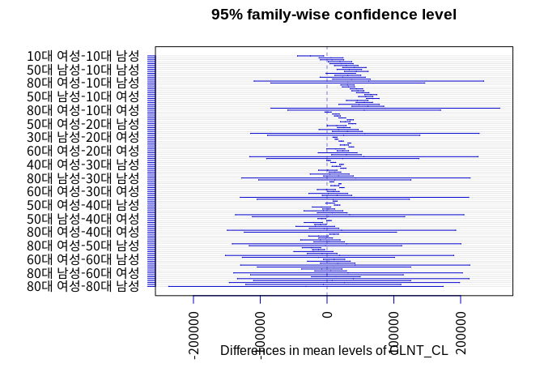

```r
fit.mcp <- TukeyHSD(fit.aov)

par(las = 2)
par(mar = c(6, 10, 3, 2))
plot(fit.mcp, col = 'mediumblue')
```

## Nomal_client 고객 그룹 분류번호

- ANOVA 결과를 토대로 평균 구매금액이 차이가 없는 집단은 합친 후, 집단을 구분할 수 있는 분류 변수를 추가한다.
1. 10대 ~ 20대 남성
2. 10대 여성
3. 20대 여성
4. 30대 남성
5. 30대 여성
6. 40대 ~ 50대 남성
7. 40대 ~ 50대 여성
8. 60대 ~ 80대 남성
9. 60대 ~ 80대 여성

```r
# 위에서 생성한 16개 집단으로 나뉜 분류변수 제거
dim(normal_client)
```

```
## [1] 599864     29
```

```r
normal_client <- normal_client[-29]

# ANOVA를 토대로 다시 고객 분류하기
normal_client[CLNT_AGE %in% c(10,20) & CLNT_GEN == 'M', 'CLNT_CL'] <- 1
normal_client[CLNT_AGE == 10 & CLNT_GEN == 'F', 'CLNT_CL'] <- 2
normal_client[CLNT_AGE == 20 & CLNT_GEN == 'F', 'CLNT_CL'] <- 3
normal_client[CLNT_AGE == 30 & CLNT_GEN == 'M', 'CLNT_CL'] <- 4
normal_client[CLNT_AGE == 30 & CLNT_GEN == 'F', 'CLNT_CL'] <- 5
normal_client[CLNT_AGE %in% c(40,50) & CLNT_GEN == 'M', 'CLNT_CL'] <- 6
normal_client[CLNT_AGE %in% c(40,50) & CLNT_GEN == 'F', 'CLNT_CL'] <- 7
normal_client[CLNT_AGE %in% c(60,70,80) & CLNT_GEN == 'M', 'CLNT_CL'] <- 8
normal_client[CLNT_AGE %in% c(60,70,80) & CLNT_GEN == 'F', 'CLNT_CL'] <- 9

str(normal_client)
```

```
## 'data.frame':    599864 obs. of  29 variables:
##  $ CLNT_ID     : num  8 14 32 56 58 59 64 68 71 73 ...
##  $ CLNT_GEN    : chr  "M" "F" "M" "F" ...
##  $ CLNT_AGE    : num  20 30 40 40 30 40 40 30 40 40 ...
##  $ HIT_AVG     : num  57 284 58 47 209 31 16 27 32 36 ...
##  $ PAG_VIEW_AVG: num  46 256 102 46 195 87 20 63 44 46 ...
##  $ SESS_CT     : int  2 1 2 2 1 2 2 5 2 2 ...
##  $ CLNT_BUY_CT : num  2 2 5 3 6 6 2 6 3 2 ...
##  $ CLNT_BUY_TOT: num  76000 69800 76800 23800 131100 ...
##  $ 전자제품    : num  0 0 0 0 0 0 0 0 0 0 ...
##  $ 리빙        : num  0 0 0 0 0 1 0 0.5 0 0 ...
##  $ 식품        : num  0 0 0 0 0 0 0 0 0 0.5 ...
##  $ 스포츠      : num  0 0 0 0 0 0 0 0 0 0 ...
##  $ 패션        : num  1 1 1 0 1 0 1 0 0.67 0.5 ...
##  $ 뷰티        : num  0 0 0 0.67 0 0 0 0.5 0.33 0 ...
##  $ 유아용품    : num  0 0 0 0.33 0 0 0 0 0 0 ...
##  $ 취미용품    : num  0 0 0 0 0 0 0 0 0 0 ...
##  $ 사무용품    : num  0 0 0 0 0 0 0 0 0 0 ...
##  $ 상품권      : num  0 0 0 0 0 0 0 0 0 0 ...
##  $ C1_CT       : num  0 0 0 0 0 0 0 0 0 0 ...
##  $ C2_CT       : num  0 0 0 0 0 6 0 3 0 0 ...
##  $ C3_CT       : num  0 0 0 0 0 0 0 0 0 1 ...
##  $ C4_CT       : num  0 0 0 0 0 0 0 0 0 0 ...
##  $ C5_CT       : num  2 2 5 0 6 0 2 0 2 1 ...
##  $ C6_CT       : num  0 0 0 2 0 0 0 3 1 0 ...
##  $ C7_CT       : num  0 0 0 1 0 0 0 0 0 0 ...
##  $ C8_CT       : num  0 0 0 0 0 0 0 0 0 0 ...
##  $ C9_CT       : num  0 0 0 0 0 0 0 0 0 0 ...
##  $ C10_CT      : num  0 0 0 0 0 0 0 0 0 0 ...
##  $ CLNT_CL     : num  1 5 6 7 5 7 7 5 7 6 ...
```

```r
normal_client <- as.data.frame(normal_client)

# rda 파일로 저장
save(normal_client, file="~/Documents/R/R_workspace/easy_r/Data/normal_client0.rda")
```

```r
detach(normal_client)
```

# 3. Vip Client 분산분석

## Vip Client 분산분석을 위해 성별, 연령별로 세분화된 집단 16개로 분류

```r
attach(vip_client)

vip_client[vip_client$CLNT_AGE == 10 & vip_client$CLNT_GEN == 'M', 'CLNT_CL'] <- '10대 남성'
vip_client[vip_client$CLNT_AGE == 10 & vip_client$CLNT_GEN == 'F', 'CLNT_CL'] <- '10대 여성'
vip_client[vip_client$CLNT_AGE == 20 & vip_client$CLNT_GEN == 'M', 'CLNT_CL'] <- '20대 남성'
vip_client[vip_client$CLNT_AGE == 20 & vip_client$CLNT_GEN == 'F', 'CLNT_CL'] <- '20대 여성'
vip_client[vip_client$CLNT_AGE == 30 & vip_client$CLNT_GEN == 'M', 'CLNT_CL'] <- '30대 남성'
vip_client[vip_client$CLNT_AGE == 30 & vip_client$CLNT_GEN == 'F', 'CLNT_CL'] <- '30대 여성'
vip_client[vip_client$CLNT_AGE == 40 & vip_client$CLNT_GEN == 'M', 'CLNT_CL'] <- '40대 남성'
vip_client[vip_client$CLNT_AGE == 40 & vip_client$CLNT_GEN == 'F', 'CLNT_CL'] <- '40대 여성'
vip_client[vip_client$CLNT_AGE == 50 & vip_client$CLNT_GEN == 'M', 'CLNT_CL'] <- '50대 남성'
vip_client[vip_client$CLNT_AGE == 50 & vip_client$CLNT_GEN == 'F', 'CLNT_CL'] <- '50대 여성'
vip_client[vip_client$CLNT_AGE == 60 & vip_client$CLNT_GEN == 'M', 'CLNT_CL'] <- '60대 남성'
vip_client[vip_client$CLNT_AGE == 60 & vip_client$CLNT_GEN == 'F', 'CLNT_CL'] <- '60대 여성'
vip_client[vip_client$CLNT_AGE == 70 & vip_client$CLNT_GEN == 'M', 'CLNT_CL'] <- '70대 남성'
vip_client[vip_client$CLNT_AGE == 70 & vip_client$CLNT_GEN == 'F', 'CLNT_CL'] <- '70대 여성'
vip_client[vip_client$CLNT_AGE == 80 & vip_client$CLNT_GEN == 'M', 'CLNT_CL'] <- '80대 남성'
vip_client[vip_client$CLNT_AGE == 80 & vip_client$CLNT_GEN == 'F', 'CLNT_CL'] <- '80대 여성'

# 범주형 변수인 CLNT_CL factor로 형변환하기
vip_client$CLNT_CL <- as.factor(vip_client$CLNT_CL)
str(vip_client)
```

```
## 'data.frame':    71640 obs. of  29 variables:
##  $ CLNT_ID     : num  63 148 291 451 461 497 556 670 678 813 ...
##  $ CLNT_GEN    : chr  "F" "F" "M" "F" ...
##  $ CLNT_AGE    : num  40 20 30 40 50 40 40 30 40 40 ...
##  $ HIT_AVG     : num  69 18 31 48 22 41 96 91 68 194 ...
##  $ PAG_VIEW_AVG: num  77 67 32 70 29 40 88 124 97 194 ...
##  $ SESS_CT     : int  5 2 3 26 4 1 34 5 2 4 ...
##  $ CLNT_BUY_CT : num  11 2 3 64 4 4 62 7 7 8 ...
##  $ CLNT_BUY_TOT: num  1333730 2200000 981800 1600600 986250 ...
##  $ 전자제품    : num  0 0 0.33 0 0.25 0.5 0.13 0.14 0 0 ...
##  $ 리빙        : num  0 0 0 0.08 0.25 0.5 0.03 0.29 0 0 ...
##  $ 식품        : num  0 0 0 0 0 0 0 0 0 0 ...
##  $ 스포츠      : num  0 0 0 0 0 0 0 0 0 0 ...
##  $ 패션        : num  0.55 1 0.33 0.53 0.25 0 0.81 0.14 0.43 1 ...
##  $ 뷰티        : num  0.45 0 0 0.39 0.25 0 0.03 0.43 0.57 0 ...
##  $ 유아용품    : num  0 0 0.33 0 0 0 0 0 0 0 ...
##  $ 취미용품    : num  0 0 0 0 0 0 0 0 0 0 ...
##  $ 사무용품    : num  0 0 0 0 0 0 0 0 0 0 ...
##  $ 상품권      : num  0 0 0 0 0 0 0 0 0 0 ...
##  $ C1_CT       : num  0 0 1 0 1 2 8 1 0 0 ...
##  $ C2_CT       : num  0 0 0 5 1 2 2 2 0 0 ...
##  $ C3_CT       : num  0 0 0 0 0 0 0 0 0 0 ...
##  $ C4_CT       : num  0 0 0 0 0 0 0 0 0 0 ...
##  $ C5_CT       : num  6 2 1 34 1 0 50 1 3 8 ...
##  $ C6_CT       : num  5 0 0 25 1 0 2 3 4 0 ...
##  $ C7_CT       : num  0 0 1 0 0 0 0 0 0 0 ...
##  $ C8_CT       : num  0 0 0 0 0 0 0 0 0 0 ...
##  $ C9_CT       : num  0 0 0 0 0 0 0 0 0 0 ...
##  $ C10_CT      : num  0 0 0 0 0 0 0 0 0 0 ...
##  $ CLNT_CL     : Factor w/ 16 levels "10대 남성","10대 여성",..: 8 4 5 8 10 8 8 6 8 8 ...
```

## 각 그룹별 구매금액 평균 구하기

```r
tapply(vip_client$CLNT_BUY_TOT, vip_client$CLNT_CL, mean)
```

```
## 10대 남성 10대 여성 20대 남성 20대 여성 30대 남성 30대 여성 40대 남성 40대 여성
##   1197596   1174190   1350581   1307464   1450635   1434700   1675906   1586350
## 50대 남성 50대 여성 60대 남성 60대 여성 70대 남성 70대 여성 80대 남성 80대 여성
##   1921981   1700800   1548999   3623352   1404259   1738342   1645000   1364072
```

## ANOVA 모형 적합

```r
fit.aov2 <- aov(CLNT_BUY_TOT ~ CLNT_CL, data = vip_client)
summary(fit.aov2)
```

```
##                Df             Sum Sq         Mean Sq F value
## CLNT_CL        15   3254692540355659 216979502690377   23.29
## Residuals   71624 667413219117668480   9318290225590
##                          Pr(>F)
## CLNT_CL     <0.0000000000000002 ***
## Residuals
## ---
## Signif. codes:  0 '***' 0.001 '**' 0.01 '*' 0.05 '.' 0.1 ' ' 1
```

```r
# --> 대립가설이 채택되며, 고도로 유의하다.
# --> 집단간 평균 구매금액은 같지 않다.
# --> 어떤 집단들이 차이가 있는지 보기 위해 사후분석이 필요하다.
```

## 사후분석 - 평균의 다중비교

```r
library(multcomp)
fit.glht2 <- glht(fit.aov2, linfct = mcp(CLNT_CL = 'Tukey'))
summary(fit.glht2)
```

```
##
##   Simultaneous Tests for General Linear Hypotheses
##
## Multiple Comparisons of Means: Tukey Contrasts
##
##
## Fit: aov(formula = CLNT_BUY_TOT ~ CLNT_CL, data = vip_client)
##
## Linear Hypotheses:
##                            Estimate Std. Error t value Pr(>|t|)
## 10대 여성 - 10대 남성 == 0   -23405     649262  -0.036   1.0000
## 20대 남성 - 10대 남성 == 0   152986     566895   0.270   1.0000
## 20대 여성 - 10대 남성 == 0   109869     559086   0.197   1.0000
## 30대 남성 - 10대 남성 == 0   253039     559504   0.452   1.0000
## 30대 여성 - 10대 남성 == 0   237104     557649   0.425   1.0000
## 40대 남성 - 10대 남성 == 0   478311     559262   0.855   0.9999
## 40대 여성 - 10대 남성 == 0   388754     557648   0.697   1.0000
## 50대 남성 - 10대 남성 == 0   724386     565397   1.281   0.9911
## 50대 여성 - 10대 남성 == 0   503204     559184   0.900   0.9998
## 60대 남성 - 10대 남성 == 0   351403     599711   0.586   1.0000
## 60대 여성 - 10대 남성 == 0  2425756     573327   4.231    <0.01 **
## 70대 남성 - 10대 남성 == 0   206663     826645   0.250   1.0000
## 70대 여성 - 10대 남성 == 0   540746     680712   0.794   1.0000
## 80대 남성 - 10대 남성 == 0   447404    3103047   0.144   1.0000
## 80대 여성 - 10대 남성 == 0   166476    1474540   0.113   1.0000
## 20대 남성 - 10대 여성 == 0   176391     348844   0.506   1.0000
## 20대 여성 - 10대 여성 == 0   133274     336005   0.397   1.0000
## 30대 남성 - 10대 여성 == 0   276444     336701   0.821   0.9999
## 30대 여성 - 10대 여성 == 0   260510     333608   0.781   1.0000
## 40대 남성 - 10대 여성 == 0   501716     336298   1.492   0.9630
## 40대 여성 - 10대 여성 == 0   412159     333607   1.235   0.9938
## 50대 남성 - 10대 여성 == 0   747791     346405   2.159   0.5924
## 50대 여성 - 10대 여성 == 0   526610     336169   1.567   0.9444
## 60대 남성 - 10대 여성 == 0   374808     399970   0.937   0.9997
## 60대 여성 - 10대 여성 == 0  2449162     359202   6.818    <0.01 ***
## 70대 남성 - 10대 여성 == 0   230068     695459   0.331   1.0000
## 70대 여성 - 10대 여성 == 0   564151     513508   1.099   0.9983
## 80대 남성 - 10대 여성 == 0   470810    3070704   0.153   1.0000
## 80대 여성 - 10대 여성 == 0   189882    1405201   0.135   1.0000
## 20대 여성 - 20대 남성 == 0   -43117     112815  -0.382   1.0000
```

[output cut: 78 more lines]

```
## 80대 남성 - 60대 남성 == 0    96001    3060610   0.031   1.0000
## 80대 여성 - 60대 남성 == 0  -184927    1383005  -0.134   1.0000
## 70대 남성 - 60대 여성 == 0 -2219093     625160  -3.550   0.0167 *
## 70대 여성 - 60대 여성 == 0 -1885010     413343  -4.560    <0.01 ***
## 80대 남성 - 60대 여성 == 0 -1978352    3055550  -0.647   1.0000
## 80대 여성 - 60대 여성 == 0 -2259280    1371770  -1.647   0.9174
## 70대 여성 - 70대 남성 == 0   334083     724907   0.461   1.0000
## 80대 남성 - 70대 남성 == 0   240741    3113041   0.077   1.0000
## 80대 여성 - 70대 남성 == 0   -40187    1495456  -0.027   1.0000
## 80대 남성 - 70대 여성 == 0   -93342    3077507  -0.030   1.0000
## 80대 여성 - 70대 여성 == 0  -374270    1420006  -0.264   1.0000
## 80대 여성 - 80대 남성 == 0  -280928    3343942  -0.084   1.0000
## ---
## Signif. codes:  0 '***' 0.001 '**' 0.01 '*' 0.05 '.' 0.1 ' ' 1
## (Adjusted p values reported -- single-step method)
```

## 사후분석 시각화

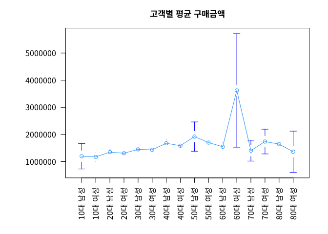

```r
library(gplots)
library(scales)
par(las = 2)
par(mar = c(6, 7, 3, 2))
plotmeans(formula = CLNT_BUY_TOT ~ CLNT_CL,
          data = vip_client,
          cex.main=1.1,
          ylab = "",
          xlab = "",
          main = "고객별 평균 구매금액",
          col = 'dodgerblue',
          n.label = F)
```

```r
TukeyHSD(fit.aov2)
```

```
##   Tukey multiple comparisons of means
##     95% family-wise confidence level
##
## Fit: aov(formula = CLNT_BUY_TOT ~ CLNT_CL, data = vip_client)
##
## $CLNT_CL
##                            diff           lwr         upr     p adj
## 10대 여성-10대 남성   -23405.19  -2247805.135  2200994.75 1.0000000
## 20대 남성-10대 남성   152985.45  -1789219.922  2095190.83 1.0000000
## 20대 여성-10대 남성   109868.80  -1805581.893  2025319.49 1.0000000
## 30대 남성-10대 남성   253039.34  -1663845.940  2169924.62 1.0000000
## 30대 여성-10대 남성   237104.27  -1673423.768  2147632.30 1.0000000
## 40대 남성-10대 남성   478310.67  -1437744.746  2394366.09 0.9999738
## 40대 여성-10대 남성   388754.10  -1521770.477  2299278.68 0.9999983
## 50대 남성-10대 남성   724385.82  -1212688.881  2661460.52 0.9965605
## 50대 여성-10대 남성   503204.46  -1412584.852  2418993.78 0.9999494
## 60대 남성-10대 남성   351403.07  -1703231.698  2406037.84 0.9999998
## 60대 여성-10대 남성  2425756.31    461515.505  4389997.12 0.0024616
## 70대 남성-10대 남성   206663.13  -2625455.448  3038781.72 1.0000000
## 70대 여성-10대 남성   540746.14  -1791400.596  2872892.87 0.9999901
## 80대 남성-10대 남성   447404.33 -10183762.657 11078571.32 1.0000000
## 80대 여성-10대 남성   166476.33  -4885358.150  5218310.82 1.0000000
## 20대 남성-10대 여성   176390.64  -1018763.534  1371544.82 1.0000000
## 20대 여성-10대 여성   133273.99  -1017892.002  1284439.98 1.0000000
## 30대 남성-10대 여성   276444.53   -877106.928  1429995.99 0.9999847
## 30대 여성-10대 여성   260509.46   -882446.866  1403465.78 0.9999921
## 40대 남성-10대 여성   501715.86   -650456.066  1653887.79 0.9836411
## 40대 여성-10대 여성   412159.29   -730791.254  1555109.84 0.9976926
## 50대 남성-10대 여성   747791.01   -439007.283  1934589.31 0.7263325
## 50대 여성-10대 여성   526609.65   -625119.693  1678339.00 0.9741671
## 60대 남성-10대 여성   374808.26   -995504.047  1745120.57 0.9999151
## 60대 여성-10대 여성  2449161.50   1218521.938  3679801.07 0.0000000
## 70대 남성-10대 여성   230068.32  -2152604.010  2612740.66 1.0000000
## 70대 여성-10대 여성   564151.33  -1195149.719  2323452.37 0.9994017
## 80대 남성-10대 여성   470809.52 -10049548.995 10991168.04 1.0000000
## 80대 여성-10대 여성   189881.52  -4624395.518  5004158.57 1.0000000
## 20대 여성-20대 남성   -43116.66   -429626.351   343393.04 1.0000000
## 30대 남성-20대 남성   100053.89   -293503.703   493611.48 0.9999668
## 30대 여성-20대 남성    84118.81   -277206.196   445443.82 0.9999895
## 40대 남성-20대 남성   325325.22    -64170.300   714820.74 0.2345480
```

[output cut: 72 more lines]

```
## 60대 여성-60대 남성  2074353.24   1186635.575  2962070.91 0.0000000
## 70대 남성-60대 남성  -144739.94  -2369755.974  2080276.10 1.0000000
## 70대 여성-60대 남성   189343.07  -1349718.040  1728404.17 1.0000000
## 80대 남성-60대 남성    96001.26 -10389775.403 10581777.93 1.0000000
## 80대 여성-60대 남성  -184926.74  -4923157.667  4553304.19 1.0000000
## 70대 남성-60대 여성 -2219093.18  -4360918.171   -77268.19 0.0333496
## 70대 여성-60대 여성 -1885010.18  -3301141.178  -468879.18 0.0005681
## 80대 남성-60대 여성 -1978351.98 -12446791.702  8490087.74 0.9999994
## 80대 여성-60대 여성 -2259279.98  -6959019.364  2440459.40 0.9597015
## 70대 여성-70대 남성   334083.00  -2149479.099  2817645.11 1.0000000
## 80대 남성-70대 남성   240741.20 -10424664.742 10906147.14 1.0000000
## 80대 여성-70대 남성   -40186.80  -5163682.089  5083308.49 1.0000000
## 80대 남성-70대 여성   -93341.80 -10637007.989 10450324.38 1.0000000
## 80대 여성-70대 여성  -374269.80  -5239268.951  4490729.34 1.0000000
## 80대 여성-80대 남성  -280928.00 -11737411.750 11175555.75 1.0000000
```

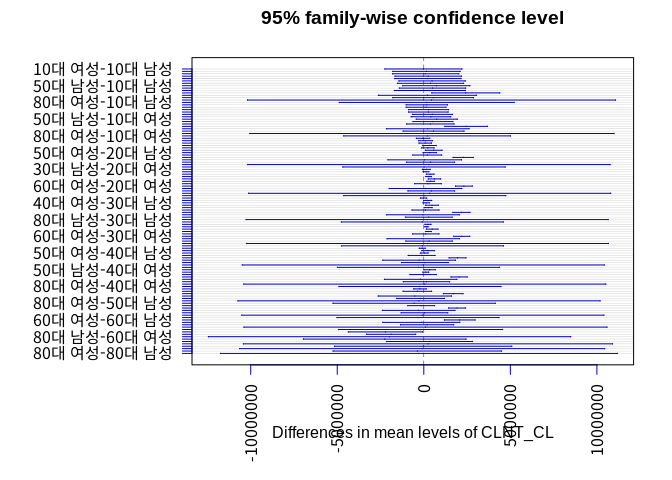

```r
fit.mcp <- TukeyHSD(fit.aov2)

par(las = 2)
par(mar = c(6, 10, 3, 2))
plot(fit.mcp, col = 'mediumblue')
```

## Vip Client 고객 그룹 분류번호

```r
# 위에서 생성한 16개 집단으로 나뉜 분류변수 제거
dim(vip_client)
```

```
## [1] 71640    29
```

```r
vip_client <- vip_client[-29]

# vip_client는 전체 client 중 10번 그룹으로 분류
vip_client$CLNT_CL <- 10

str(vip_client)
```

```
## 'data.frame':    71640 obs. of  29 variables:
##  $ CLNT_ID     : num  63 148 291 451 461 497 556 670 678 813 ...
##  $ CLNT_GEN    : chr  "F" "F" "M" "F" ...
##  $ CLNT_AGE    : num  40 20 30 40 50 40 40 30 40 40 ...
##  $ HIT_AVG     : num  69 18 31 48 22 41 96 91 68 194 ...
##  $ PAG_VIEW_AVG: num  77 67 32 70 29 40 88 124 97 194 ...
##  $ SESS_CT     : int  5 2 3 26 4 1 34 5 2 4 ...
##  $ CLNT_BUY_CT : num  11 2 3 64 4 4 62 7 7 8 ...
##  $ CLNT_BUY_TOT: num  1333730 2200000 981800 1600600 986250 ...
##  $ 전자제품    : num  0 0 0.33 0 0.25 0.5 0.13 0.14 0 0 ...
##  $ 리빙        : num  0 0 0 0.08 0.25 0.5 0.03 0.29 0 0 ...
##  $ 식품        : num  0 0 0 0 0 0 0 0 0 0 ...
##  $ 스포츠      : num  0 0 0 0 0 0 0 0 0 0 ...
##  $ 패션        : num  0.55 1 0.33 0.53 0.25 0 0.81 0.14 0.43 1 ...
##  $ 뷰티        : num  0.45 0 0 0.39 0.25 0 0.03 0.43 0.57 0 ...
##  $ 유아용품    : num  0 0 0.33 0 0 0 0 0 0 0 ...
##  $ 취미용품    : num  0 0 0 0 0 0 0 0 0 0 ...
##  $ 사무용품    : num  0 0 0 0 0 0 0 0 0 0 ...
##  $ 상품권      : num  0 0 0 0 0 0 0 0 0 0 ...
##  $ C1_CT       : num  0 0 1 0 1 2 8 1 0 0 ...
##  $ C2_CT       : num  0 0 0 5 1 2 2 2 0 0 ...
##  $ C3_CT       : num  0 0 0 0 0 0 0 0 0 0 ...
##  $ C4_CT       : num  0 0 0 0 0 0 0 0 0 0 ...
##  $ C5_CT       : num  6 2 1 34 1 0 50 1 3 8 ...
##  $ C6_CT       : num  5 0 0 25 1 0 2 3 4 0 ...
##  $ C7_CT       : num  0 0 1 0 0 0 0 0 0 0 ...
##  $ C8_CT       : num  0 0 0 0 0 0 0 0 0 0 ...
##  $ C9_CT       : num  0 0 0 0 0 0 0 0 0 0 ...
##  $ C10_CT      : num  0 0 0 0 0 0 0 0 0 0 ...
##  $ CLNT_CL     : num  10 10 10 10 10 10 10 10 10 10 ...
```

```r
vip_client <- as.data.frame(vip_client)

# rda 파일로 저장
save(vip_client, file="~/Documents/R/R_workspace/easy_r/Data/vip_client0.rda")
```

```r
detach(vip_client)
```

# 4. Normal/Vip Client Clustering

- 위에서 분류한 9개의 Normal와 1개의 vip client로 분류한 총 10개의 집단에 고객별 카테고리 구매 비율 변수를 기준으로 클러스터링을 수행하여, 구매 특성에 따라 집단을 세분화한다.

```r
# 필요한 패키지 로드
library(NbClust)
library(dplyr)
library(pls)
```

## 클러스터링 함수 생성

```r
# 군집개수 2개로 정한 후, 클러스터링 수행하는 함수 생성
# type(1~10 분류) , num = set.seed(12)
all_client <- rbind(normal_client, vip_client)

cluster_func <- function(all_client, type = c(1:10), num = c(1:1000) ) {

  # Class별 테이블 생성
  Class_table <- all_client %>%
    filter(CLNT_CL == type)

  Class_table <- Class_table[9:18]

  set.seed(num)
  fit.kmeans <- kmeans(Class_table, centers = 2)

  return(fit.kmeans)
}
```

## (1) 10~20대 남성 클러스터링 수행

```r
# type = 1 (10~20대 남성 그룹 클러스터링)
fit.kmeans <- cluster_func(all_client, 1, 3)

# Class_table에 클러스터링한 변수 넣기
all_client[all_client$CLNT_CL == 1, "Cluster_Num"] <- fit.kmeans$cluster

# 변수 들어갔는지 확인하기
a <- all_client %>% filter(CLNT_CL == 1)
str(a)
```

```
## 'data.frame':    12922 obs. of  30 variables:
##  $ CLNT_ID     : num  8 215 662 780 1209 ...
##  $ CLNT_GEN    : chr  "M" "M" "M" "M" ...
##  $ CLNT_AGE    : num  20 20 20 20 20 20 20 20 10 20 ...
##  $ HIT_AVG     : num  57 296 74 50 35 57 20 38 50 65 ...
##  $ PAG_VIEW_AVG: num  46 251 59 52 34 60 19 38 69 77 ...
##  $ SESS_CT     : int  2 3 1 2 1 4 1 2 3 3 ...
##  $ CLNT_BUY_CT : num  2 4 2 4 2 4 2 2 3 3 ...
##  $ CLNT_BUY_TOT: num  76000 248120 199000 148000 58520 ...
##  $ 전자제품    : num  0 0.25 0 0 0 0 0 0 0 0 ...
##  $ 리빙        : num  0 0 0 0 0 0 0 0 0 0 ...
##  $ 식품        : num  0 0 0 0 0 0 0 0 0 0 ...
##  $ 스포츠      : num  0 0 0 0 0 1 0 0 0 0 ...
##  $ 패션        : num  1 0.75 1 0 1 0 1 1 0.67 1 ...
##  $ 뷰티        : num  0 0 0 1 0 0 0 0 0.33 0 ...
```

[output cut: 16 more lines]

## (2) 10대 여성 클러스터링 수행

```r
# type = 2 (10대 여성 그룹 클러스터링)
fit.kmeans <- cluster_func(all_client, 2, 3)

# Class_table에 클러스터링한 변수 넣기
all_client[all_client$CLNT_CL == 2, "Cluster_Num"] <- fit.kmeans$cluster

# 변수 들어갔는지 확인하기
a <- all_client %>% filter(CLNT_CL == 2)
str(a)
```

```
## 'data.frame':    2923 obs. of  30 variables:
##  $ CLNT_ID     : num  1030 2850 3089 3529 5179 ...
##  $ CLNT_GEN    : chr  "F" "F" "F" "F" ...
##  $ CLNT_AGE    : num  10 10 10 10 10 10 10 10 10 10 ...
##  $ HIT_AVG     : num  26 220 106 60 263 138 20 15 67 57 ...
##  $ PAG_VIEW_AVG: num  32 202 85 53 286 178 30 28 100 49 ...
##  $ SESS_CT     : int  2 4 2 2 2 1 2 1 2 1 ...
##  $ CLNT_BUY_CT : num  2 6 2 2 3 2 2 2 2 2 ...
##  $ CLNT_BUY_TOT: num  270000 236200 170200 276000 144600 ...
##  $ 전자제품    : num  0 0 0 0 0 0 0 0 0 0 ...
##  $ 리빙        : num  0 0 0 0 0 0 0 0 0 0 ...
##  $ 식품        : num  0 0 0 0 0 0 0 0 0 0 ...
##  $ 스포츠      : num  0 0 0 0 0 1 0 0 0 0 ...
##  $ 패션        : num  0.5 0.5 1 1 1 0 1 1 0 1 ...
##  $ 뷰티        : num  0.5 0.5 0 0 0 0 0 0 1 0 ...
```

[output cut: 16 more lines]

## (3) 20대 여성 클러스터링 수행

```r
# type = 3 (20대 여성 그룹 클러스터링)
fit.kmeans <- cluster_func(all_client, 3, 3)

# Class_table에 클러스터링한 변수 넣기
all_client[all_client$CLNT_CL == 3, "Cluster_Num"] <- fit.kmeans$cluster

# 변수 들어갔는지 확인하기
a <- all_client %>% filter(CLNT_CL == 3)
str(a)
```

```
## 'data.frame':    77509 obs. of  30 variables:
##  $ CLNT_ID     : num  114 200 421 434 698 741 759 791 802 846 ...
##  $ CLNT_GEN    : chr  "F" "F" "F" "F" ...
##  $ CLNT_AGE    : num  20 20 20 20 20 20 20 20 20 20 ...
##  $ HIT_AVG     : num  224 64 78 20 33 43 48 190 70 5 ...
##  $ PAG_VIEW_AVG: num  219 65 92 19 38 44 46 244 81 37 ...
##  $ SESS_CT     : int  1 3 1 51 3 2 3 1 1 1 ...
##  $ CLNT_BUY_CT : num  3 4 2 52 4 2 3 2 4 3 ...
##  $ CLNT_BUY_TOT: num  231000 383800 90000 593300 283020 ...
##  $ 전자제품    : num  0 0 0 0 0.5 0 0 0 0 0 ...
##  $ 리빙        : num  0 0.75 0 0 0 0 0 0 0 0 ...
##  $ 식품        : num  0 0 0 1 0 0 0 0 0 0 ...
##  $ 스포츠      : num  0 0 0 0 0 0 0 0 0 0 ...
##  $ 패션        : num  0 0 1 0 0.25 1 0.67 0 0 1 ...
##  $ 뷰티        : num  1 0.25 0 0 0.25 0 0 1 1 0 ...
```

[output cut: 16 more lines]

## (4) 30대 남성 클러스터링 수행

```r
# type = 4 (30대 남성 그룹 클러스터링)
fit.kmeans <- cluster_func(all_client, 4, 3)

# Class_table에 클러스터링한 변수 넣기
all_client[all_client$CLNT_CL == 4, "Cluster_Num"] <- fit.kmeans$cluster

# 변수 들어갔는지 확인하기
a <- all_client %>% filter(CLNT_CL == 4)
str(a)
```

```
## 'data.frame':    38043 obs. of  30 variables:
##  $ CLNT_ID     : num  252 536 749 823 898 ...
##  $ CLNT_GEN    : chr  "M" "M" "M" "M" ...
##  $ CLNT_AGE    : num  30 30 30 30 30 30 30 30 30 30 ...
##  $ HIT_AVG     : num  20 36 97 26 32 25 62 30 26 50 ...
##  $ PAG_VIEW_AVG: num  31 32 116 41 26 32 90 33 34 48 ...
##  $ SESS_CT     : int  1 2 2 1 1 2 2 3 2 1 ...
##  $ CLNT_BUY_CT : num  1 2 3 1 2 3 3 3 2 1 ...
##  $ CLNT_BUY_TOT: num  61750 64000 156000 252000 67200 ...
##  $ 전자제품    : num  0 0 0 0 0 0.67 0.67 0 0 0 ...
##  $ 리빙        : num  0 0 0 0 0 0 0 0 0 0 ...
##  $ 식품        : num  0 0 0 0 0 0 0.33 0.33 0 0 ...
##  $ 스포츠      : num  0 0 0 0 0 0 0 0 0.5 0 ...
##  $ 패션        : num  0 0 1 1 1 0.33 0 0.33 0.5 1 ...
##  $ 뷰티        : num  0 1 0 0 0 0 0 0.33 0 0 ...
```

[output cut: 16 more lines]

## (5) 30대 여성 클러스터링 수행

```r
# type = 5 (30대 여성 그룹 클러스터링)
fit.kmeans <- cluster_func(all_client, 5, 3)

# Class_table에 클러스터링한 변수 넣기
all_client[all_client$CLNT_CL == 5, "Cluster_Num"] <- fit.kmeans$cluster

# 변수 들어갔는지 확인하기
a <- all_client %>% filter(CLNT_CL == 5)
str(a)
```

```
## 'data.frame':    245938 obs. of  30 variables:
##  $ CLNT_ID     : num  14 58 68 78 89 121 129 222 254 257 ...
##  $ CLNT_GEN    : chr  "F" "F" "F" "F" ...
##  $ CLNT_AGE    : num  30 30 30 30 30 30 30 30 30 30 ...
##  $ HIT_AVG     : num  284 209 27 55 73 58 39 66 141 44 ...
##  $ PAG_VIEW_AVG: num  256 195 63 47 60 61 82 73 142 46 ...
##  $ SESS_CT     : int  1 1 5 1 1 2 2 2 4 2 ...
##  $ CLNT_BUY_CT : num  2 6 6 2 1 2 3 2 7 2 ...
##  $ CLNT_BUY_TOT: num  69800 131100 401000 34700 25000 ...
##  $ 전자제품    : num  0 0 0 0 0 0 0 0.5 0 0 ...
##  $ 리빙        : num  0 0 0.5 0 0 0 0 0 0 0 ...
##  $ 식품        : num  0 0 0 0 0 0 0 0 0 0 ...
##  $ 스포츠      : num  0 0 0 0 0 0 0 0 0 0 ...
##  $ 패션        : num  1 1 0 0 1 1 0.67 0.5 0.71 1 ...
##  $ 뷰티        : num  0 0 0.5 0 0 0 0.33 0 0.29 0 ...
```

[output cut: 16 more lines]

## (6) 40~50대 남성 클러스터링 수행

```r
# type = 6 (40~50대 남성 그룹 클러스터링)
fit.kmeans <- cluster_func(all_client, 6, 3)

# Class_table에 클러스터링한 변수 넣기
all_client[all_client$CLNT_CL == 6, "Cluster_Num"] <- fit.kmeans$cluster

# 변수 들어갔는지 확인하기
a <- all_client %>% filter(CLNT_CL == 6)
str(a)
```

```
## 'data.frame':    38220 obs. of  30 variables:
##  $ CLNT_ID     : num  32 73 93 135 305 ...
##  $ CLNT_GEN    : chr  "M" "M" "M" "M" ...
##  $ CLNT_AGE    : num  40 40 40 40 40 40 40 50 40 40 ...
##  $ HIT_AVG     : num  58 36 12 81 118 40 132 132 54 38 ...
##  $ PAG_VIEW_AVG: num  102 46 11 82 144 41 177 163 68 38 ...
##  $ SESS_CT     : int  2 2 1 4 2 5 1 5 1 1 ...
##  $ CLNT_BUY_CT : num  5 2 2 6 10 5 14 11 2 5 ...
##  $ CLNT_BUY_TOT: num  76800 142200 78000 398600 405660 ...
##  $ 전자제품    : num  0 0 0 0 0 0 0 0.09 0 0 ...
##  $ 리빙        : num  0 0 0 0 0 0 1 0.27 0 0 ...
##  $ 식품        : num  0 0.5 0 0 0 0 0 0 0 0 ...
##  $ 스포츠      : num  0 0 1 0 0 0 0 0 0 0 ...
##  $ 패션        : num  1 0.5 0 1 0 0.6 0 0.45 0 0 ...
##  $ 뷰티        : num  0 0 0 0 0 0.4 0 0.18 1 0 ...
```

[output cut: 16 more lines]

## (7) 40~50대 여성 클러스터링 수행

```r
# type = 7 (40~50대 여성 그룹 클러스터링)
fit.kmeans <- cluster_func(all_client, 7, 3)

# Class_table에 클러스터링한 변수 넣기
all_client[all_client$CLNT_CL == 7, "Cluster_Num"] <- fit.kmeans$cluster

# 변수 들어갔는지 확인하기
a <- all_client %>% filter(CLNT_CL == 7)
str(a)
```

```
## 'data.frame':    178975 obs. of  30 variables:
##  $ CLNT_ID     : num  56 59 64 71 104 106 156 159 178 212 ...
##  $ CLNT_GEN    : chr  "F" "F" "F" "F" ...
##  $ CLNT_AGE    : num  40 40 40 40 40 40 40 40 40 40 ...
##  $ HIT_AVG     : num  47 31 16 32 46 169 170 73 99 79 ...
##  $ PAG_VIEW_AVG: num  46 87 20 44 39 167 124 110 269 64 ...
##  $ SESS_CT     : int  2 2 2 2 2 1 4 3 1 1 ...
##  $ CLNT_BUY_CT : num  3 6 2 3 4 2 9 5 2 2 ...
##  $ CLNT_BUY_TOT: num  23800 91600 61800 156500 319200 ...
##  $ 전자제품    : num  0 0 0 0 0 0 0 0 0 0 ...
##  $ 리빙        : num  0 1 0 0 0 0 0 0 0 0 ...
##  $ 식품        : num  0 0 0 0 0 0 0.11 0 1 0 ...
##  $ 스포츠      : num  0 0 0 0 0 0 0.44 0 0 0 ...
##  $ 패션        : num  0 0 1 0.67 1 1 0.11 0.4 0 0 ...
##  $ 뷰티        : num  0.67 0 0 0.33 0 0 0.33 0 0 1 ...
```

[output cut: 16 more lines]

## (8) 60~80대 남성 클러스터링 수행

```r
# type = 8 (60~80대 남성 그룹 클러스터링)
fit.kmeans <- cluster_func(all_client, 8, 3)

# Class_table에 클러스터링한 변수 넣기
all_client[all_client$CLNT_CL == 8, "Cluster_Num"] <- fit.kmeans$cluster

# 변수 들어갔는지 확인하기
a <- all_client %>% filter(CLNT_CL == 8)
str(a)
```

```
## 'data.frame':    1567 obs. of  30 variables:
##  $ CLNT_ID     : num  230 1967 3068 6749 11833 ...
##  $ CLNT_GEN    : chr  "M" "M" "M" "M" ...
##  $ CLNT_AGE    : num  60 60 60 60 60 60 60 60 60 60 ...
##  $ HIT_AVG     : num  113 66 14 80 32 50 34 39 70 128 ...
##  $ PAG_VIEW_AVG: num  117 84 18 78 41 48 32 40 76 122 ...
##  $ SESS_CT     : int  2 2 1 2 2 1 1 3 2 7 ...
##  $ CLNT_BUY_CT : num  2 2 1 2 7 2 2 10 5 13 ...
##  $ CLNT_BUY_TOT: num  590000 133900 58500 152000 61700 ...
##  $ 전자제품    : num  0 0 0 0 0 0 0 0 0 0 ...
##  $ 리빙        : num  0 0 0 0 0 0 0 0 0 0.08 ...
##  $ 식품        : num  0 0.5 0 0 0.14 0 0 1 1 0.08 ...
##  $ 스포츠      : num  0 0 0 0 0 0 0 0 0 0.08 ...
##  $ 패션        : num  1 0.5 0 1 0 1 0 0 0 0.38 ...
##  $ 뷰티        : num  0 0 0 0 0 0 1 0 0 0.08 ...
```

[output cut: 16 more lines]

## (9) 60~80대 여성 클러스터링 수행

```r
# type = 9 (60~80대 여성 그룹 클러스터링)
fit.kmeans <- cluster_func(all_client, 9, 3)

# Class_table에 클러스터링한 변수 넣기
all_client[all_client$CLNT_CL == 9, "Cluster_Num"] <- fit.kmeans$cluster

# 변수 들어갔는지 확인하기
a <- all_client %>% filter(CLNT_CL == 9)
str(a)
```

```
## 'data.frame':    3767 obs. of  30 variables:
##  $ CLNT_ID     : num  886 1778 2559 3373 4604 ...
##  $ CLNT_GEN    : chr  "F" "F" "F" "F" ...
##  $ CLNT_AGE    : num  60 60 60 60 60 60 70 60 70 60 ...
##  $ HIT_AVG     : num  85 46 125 56 47 103 74 107 12 29 ...
##  $ PAG_VIEW_AVG: num  94 78 124 49 67 204 108 166 24 44 ...
##  $ SESS_CT     : int  1 2 1 1 3 2 1 5 2 1 ...
##  $ CLNT_BUY_CT : num  2 2 2 2 3 5 2 6 2 2 ...
##  $ CLNT_BUY_TOT: num  144000 42500 74900 28800 371000 ...
##  $ 전자제품    : num  0 0 0 0 0 0 1 0 0.5 0 ...
##  $ 리빙        : num  0 0 0 0 0 0 0 0 0 0 ...
##  $ 식품        : num  0 0 0 0 0.67 0 0 0.17 0.5 0 ...
##  $ 스포츠      : num  1 0 0 0 0 0 0 0 0 0 ...
##  $ 패션        : num  0 1 1 0 0.33 0 0 0.5 0 1 ...
##  $ 뷰티        : num  0 0 0 1 0 0 0 0.17 0 0 ...
```

[output cut: 16 more lines]

## (10) Vip Client 클러스터링 수행

```r
# type = 9 (60~80대 여성 그룹 클러스터링)
fit.kmeans <- cluster_func(vip_client, 10, 3)

# Class_table에 클러스터링한 변수 넣기
all_client[all_client$CLNT_CL == 10, "Cluster_Num"] <- fit.kmeans$cluster

# 변수 들어갔는지 확인하기
a <- all_client %>% filter(CLNT_CL == 10)
str(a)
```

```
## 'data.frame':    71640 obs. of  30 variables:
##  $ CLNT_ID     : num  63 148 291 451 461 497 556 670 678 813 ...
##  $ CLNT_GEN    : chr  "F" "F" "M" "F" ...
##  $ CLNT_AGE    : num  40 20 30 40 50 40 40 30 40 40 ...
##  $ HIT_AVG     : num  69 18 31 48 22 41 96 91 68 194 ...
##  $ PAG_VIEW_AVG: num  77 67 32 70 29 40 88 124 97 194 ...
##  $ SESS_CT     : int  5 2 3 26 4 1 34 5 2 4 ...
##  $ CLNT_BUY_CT : num  11 2 3 64 4 4 62 7 7 8 ...
##  $ CLNT_BUY_TOT: num  1333730 2200000 981800 1600600 986250 ...
##  $ 전자제품    : num  0 0 0.33 0 0.25 0.5 0.13 0.14 0 0 ...
##  $ 리빙        : num  0 0 0 0.08 0.25 0.5 0.03 0.29 0 0 ...
##  $ 식품        : num  0 0 0 0 0 0 0 0 0 0 ...
##  $ 스포츠      : num  0 0 0 0 0 0 0 0 0 0 ...
##  $ 패션        : num  0.55 1 0.33 0.53 0.25 0 0.81 0.14 0.43 1 ...
##  $ 뷰티        : num  0.45 0 0 0.39 0.25 0 0.03 0.43 0.57 0 ...
```

[output cut: 16 more lines]

```r
# Clustering Num을 넣은 all_client에서 다시 Normal / Vip로 분할
normal_client <- all_client[all_client$CLNT_CL < 10, ]
vip_client <- all_client[all_client$CLNT_CL == 10, ]

# rda파일로 저장
save(normal_client, file="~/Documents/R/R_workspace/easy_r/Data/normal_client0.rda")
save(vip_client, file="~/Documents/R/R_workspace/easy_r/Data/vip_client0.rda")
```